# Estimacion de Parametros

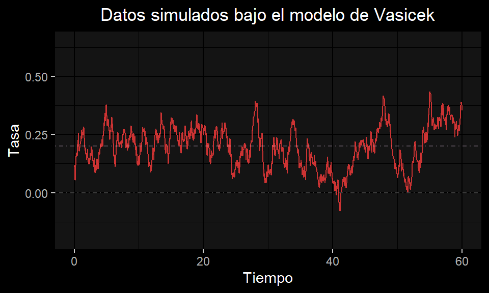

```
##                        alpha       r_e      sigma    logL
## iteraciones:  4000 0.5907624 0.2040513 0.09609999 3632.79
```

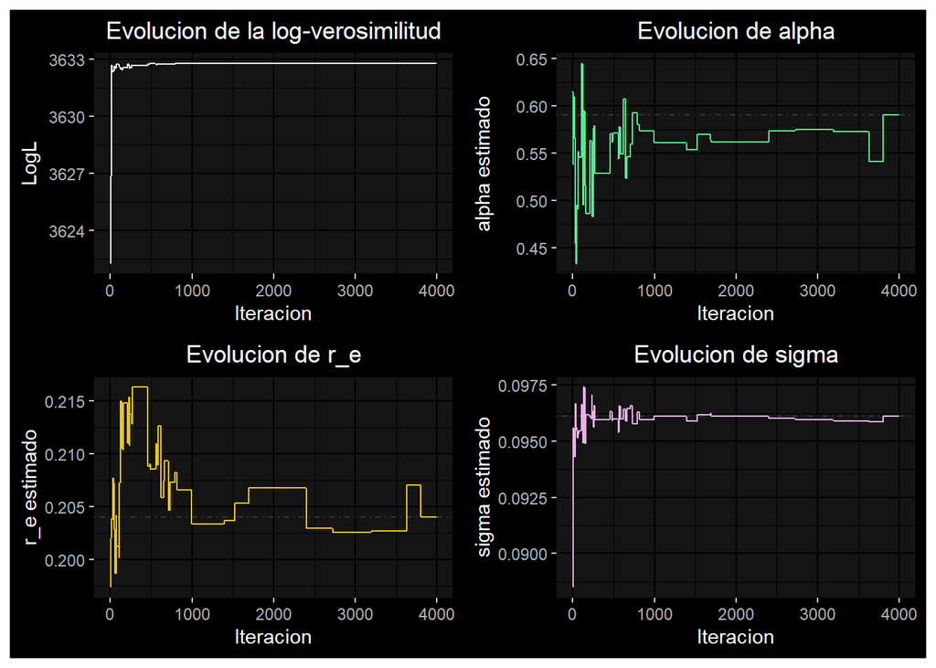

La estimacion es magnifica, casi perfecta. Concluyamos esta etapa de experimentos llevando esta idea cerca del extremo: con observaciones cada 15 minutos para analizar si tal volumen de datos (7200 observaciones) puede llegar a afectar la precision de las estimaciones en lugar de mejorarlas, ya que tal “cantidad” de aleatoriedad podria tener un impacto.

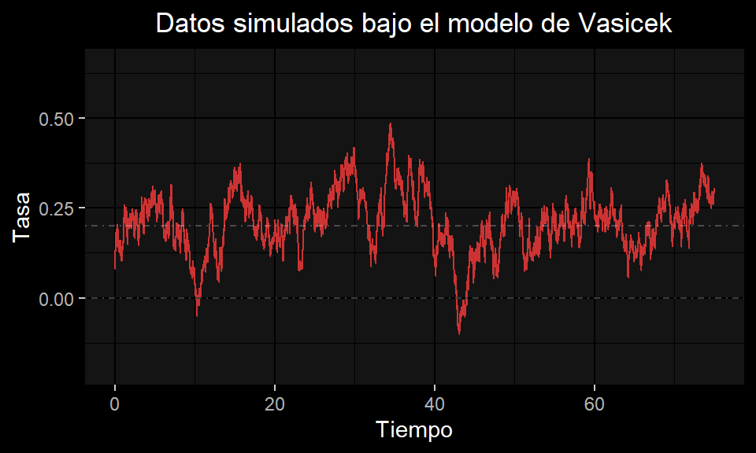

```
##                        alpha       r_e      sigma     logL
## iteraciones:  4000 0.6696481 0.2109751 0.09909719 22876.55
```

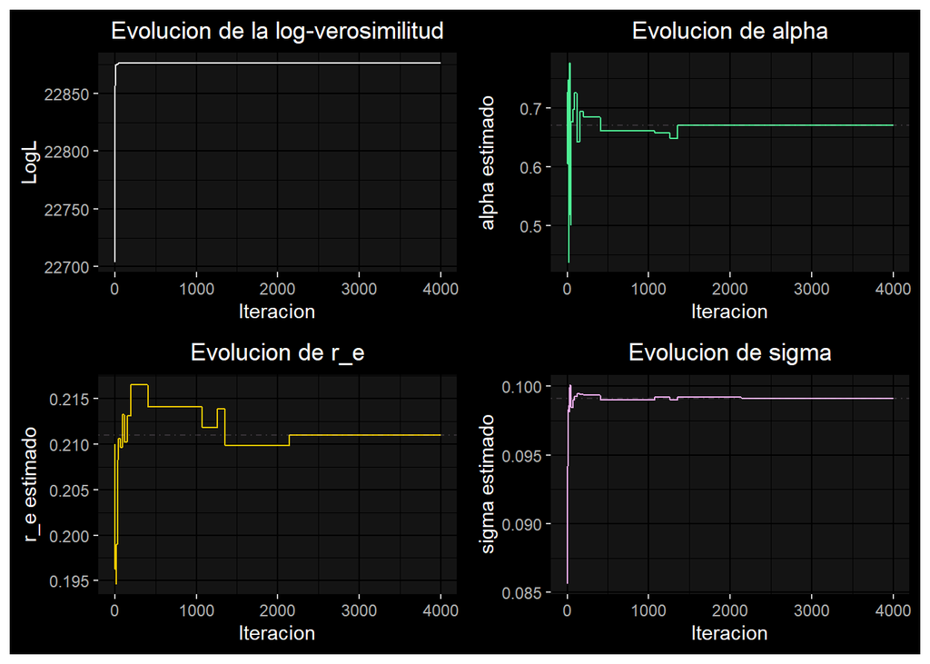

Las estimaciones siguen siendo: extraordinariamente buena para $\sigma$, muy buena para $r_e$ y aceptable para $\alpha$

#### Experimento vi

Como experimento adicional, probemoslo para un valor muy pequeño para $\alpha$

- $t_f = 60$,
- $\Delta t = 1$,
- $r_0 = 0.06$,
- $\theta \, = \, (\, \alpha, \, r_e, \, \sigma\, ) \, = \, (\, 0.16,\,0.13,\,0.09\,)$

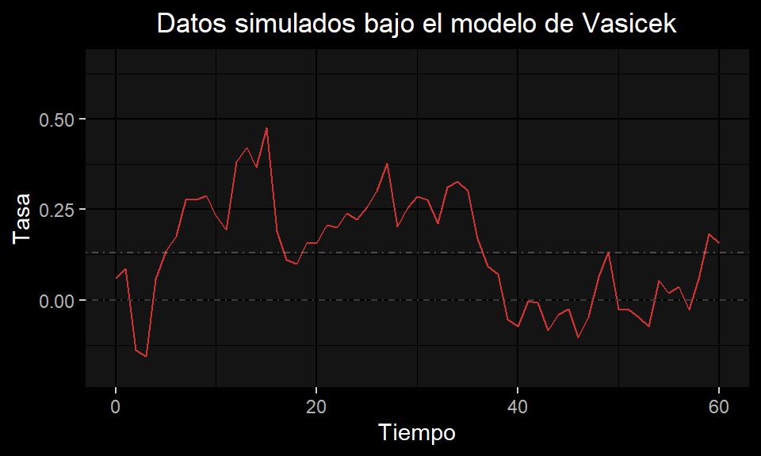

```
##                        alpha       r_e      sigma     logL
## iteraciones:  4000 0.1914305 0.1414354 0.09461215 60.21589
```

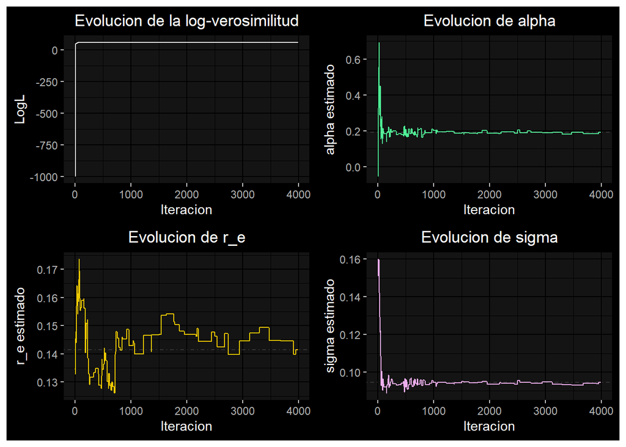

La estimacion es extraordinariamente buena. Ahora observaciones mensuales con un tamaño de paso pequeño

- $t_f = 182$,
- $\Delta t = 1$,
- $r_0 = 0.06$,
- $\theta \, = \, (\, \alpha, \, r_e, \, \sigma\, ) \, = \, (\, 0.16,\,0.13,\,0.09\,)$

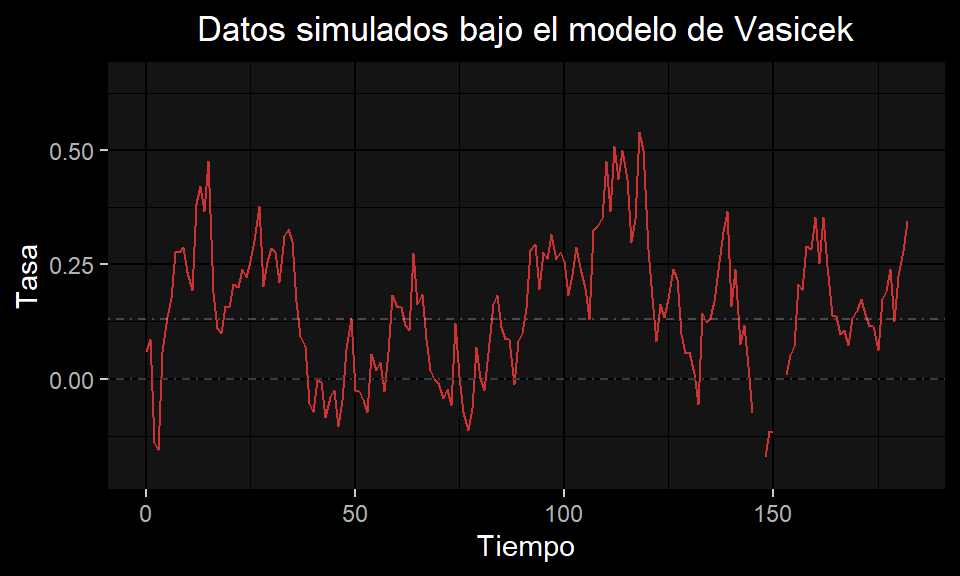

```
##                        alpha       r_e      sigma     logL
## iteraciones:  4000 0.1669816 0.1557881 0.08994054 192.6651
```

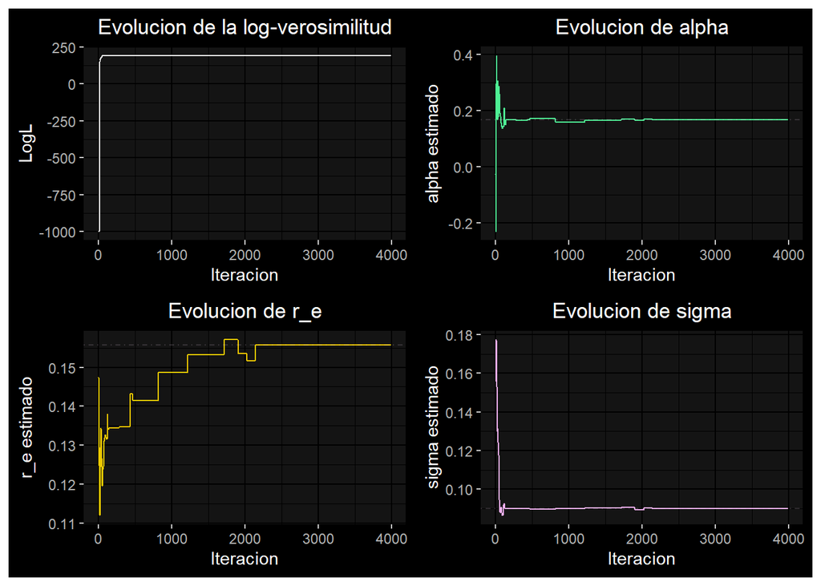

Las estimaciones son realmente muy buenas. Parece que con valores altos de $\alpha$ es en donde es mas dificil de estimar. Esto se debe al valor esperado del proceso ${r_t}$:

Recordemos que cuando resolvimos la EDE, habiamos llegado a esta expresion *(a tiempo continuo, sin discretizar)* de la distribucion de la solucion exacta:

$$r_t \, \sim \, \mathbb{N}( \, \mu_t, \, \sigma_t^2 \,)$$
por lo que tomando esperanza y sustituyendo por la expresion de $\mu_t$:

$$\mathbb{E}[\, r_t \,] \, = \, \mathbb{E}[\, \mu_t \,] = \mathbb{E}[\,
\mu_t \,] \, = \, r_e \, + \, (r_0 \, - \, r_e) \, e^{-\alpha \, t}$$

Lo cual es una funcion deterministica del tiempo y se ve asi *(para $r_e = 0.15$)*

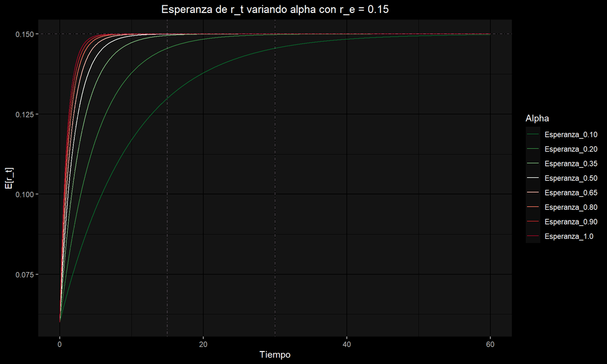

Observese que cuando ha transcurrido mas de 1 mes, solo cuando $\alpha <= 0.1$, la esperanza se puede distinguir de $r_e$ y cuando ha transcurrido mas de medio mes esto ocurre solo cuando $\alpha <= 0.2$. Probemos para un valor mas grande de $r_e$

[figure not shown]

$r_e$ se ha duplicado pero aun asi, ocurre lo mismo. Esto exhibe un poco de la dinamica detras de la influencia del parametro $\alpha$ que hace que sea dificil de estimar, almenos bastante mas que los otros dos.